# Отчёт по лабораторной работе №2

Имитационное моделирование

Автор

принадлежность

Кудякова София Андреевна

Российский университет дружбы народов

# 1 Цель работы

Познакомиться с моделями SIR и Лотки–Вольтерры, реализовать их средствами Julia, выполнить численное моделирование и исследовать влияние параметров моделей на получаемые результаты.

# 2 Задание

В ходе лабораторной работы необходимо:

- создать рабочий каталог для программного кода;
- установить необходимые пакеты;
- выполнить предложенный программный код;
- реализовать модели SIR и Лотки–Вольтерры;
- преобразовать код в литературный стиль;
- сгенерировать из литературного кода:
  - чистый код;
  - Jupyter Notebook;
  - документацию в формате Quarto;
- выполнить код из Jupyter Notebook;
- интегрировать документацию в формате Quarto в отчёт;
- добавить вычисления для набора параметров;
- выполнить параметрическое исследование моделей;
- проанализировать полученные результаты.

# 3 Теоретическое введение

## 3.1 Модель SIR

Название модели образовано от трёх групп населения:

- **Susceptible (S)** — восприимчивые к заболеванию;
- **Infectious (I)** — инфицированные;
- **Recovered (R)** — выздоровевшие.

Общая численность популяции определяется выражением:

$$N = S + I + R.$$

Модель описывается системой дифференциальных уравнений:

$$\frac{dS}{dt} = -\beta c \frac{SI}{N},$$

$$\frac{dI}{dt} = \beta c \frac{SI}{N} - \gamma I,$$

$$\frac{dR}{dt} = \gamma I.$$

Здесь $\beta$ — вероятность передачи инфекции при контакте, $c$ — среднее число контактов, а $\gamma$ — скорость выздоровления.

Базовое репродуктивное число определяется выражением:

$$R_0 = \frac{\beta c}{\gamma}.$$

Если $R_0 > 1$, инфекция может распространяться среди популяции.

Модель позволяет исследовать изменение численности восприимчивых, инфицированных и выздоровевших людей во времени, а также определить пик эпидемии и его момент.

## 3.2 Модель Лотки–Вольтерры

Пусть $x$ — численность жертв, а $y$ — численность хищников.

Модель задаётся системой:

$$\frac{dx}{dt} = \alpha x - \beta xy,$$

$$\frac{dy}{dt} = \delta xy - \gamma y.$$

Здесь:

- $\alpha$ — скорость естественного размножения жертв;
- $\beta$ — коэффициент взаимодействия жертв и хищников;
- $\delta$ — коэффициент преобразования потреблённых ресурсов в прирост хищников;
- $\gamma$ — скорость естественной смертности хищников.

Модель описывает циклическое изменение численности двух взаимодействующих популяций.

При увеличении количества жертв создаются условия для роста популяции хищников. Рост числа хищников, в свою очередь, приводит к уменьшению количества жертв. После уменьшения количества жертв численность хищников также начинает снижаться, что создаёт условия для нового роста популяции жертв.

# 4 Выполнение лабораторной работы

В ходе выполнения лабораторной работы были реализованы модели SIR и Лотки–Вольтерры с использованием языка программирования Julia.

Для организации проекта использовалась структура Julia-проекта с отдельными каталогами для исходного кода, Jupyter Notebook, документов Quarto и графических результатов.

Основная структура проекта имеет вид:

```
project/
├── markdown/
├── notebooks/
├── plots/
├── scripts/
├── src/
├── Project.toml
└── Manifest.toml
```

Структура рабочего проекта представлена на рисунке Рисунок 1.

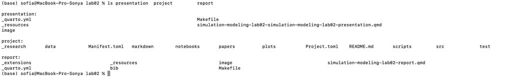

Рисунок 1: Структура рабочего проекта

## 4.1 Подготовка программного окружения

Для выполнения лабораторной работы были установлены необходимые пакеты Julia. После настройки проекта была выполнена проверка рабочего окружения.

Результат проверки представлен на рисунке Рисунок 2.

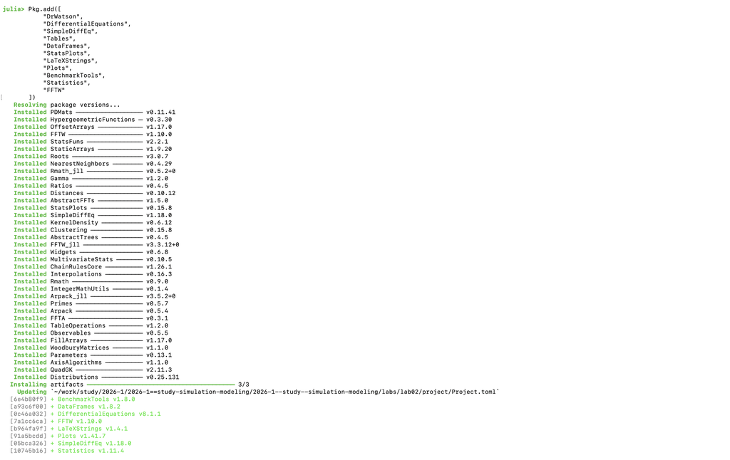

Рисунок 2: Проверка рабочего окружения

# 5 Модель SIR

## 5.1 Базовая реализация

Для реализации модели SIR был создан Julia-скрипт `sir_ode.jl`.

В программе задаются параметры модели:

$$\beta = 0.05,\quad c = 10.0,\quad \gamma = 0.25.$$

Начальные условия имеют вид:

$$S_0 = 990,\quad I_0 = 10,\quad R_0 = 0.$$

Для выбранных параметров базовое репродуктивное число равно:

$$R_0 = \frac{0.05 \cdot 10}{0.25} = 2.$$

Средняя продолжительность болезни составляет:

$$\frac{1}{\gamma} = 4$$

дня.

Результат выполнения модели SIR представлен на рисунке Рисунок 3.

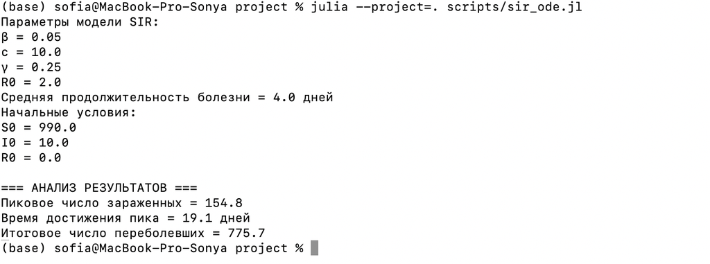

Рисунок 3: Результат выполнения модели SIR

В результате базового эксперимента получено максимальное число инфицированных:

$$I_{\max} = 154.8.$$

Пик эпидемии достигается примерно на:

$$t_{\text{peak}} = 19.1$$

дня.

Итоговое число выздоровевших составляет:

$$R(\infty) = 775.7.$$

## 5.2 Графики модели SIR

В процессе моделирования были построены графики динамики основных переменных модели.

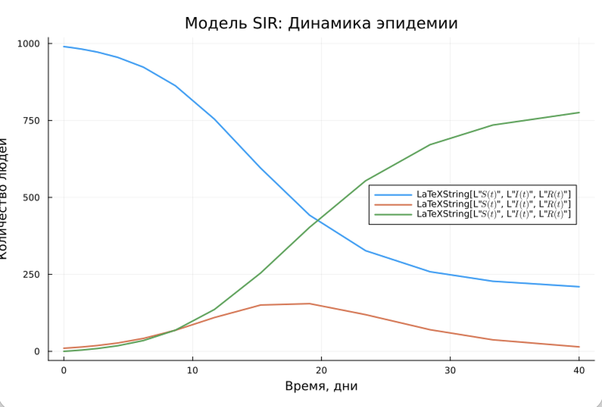

Рисунок 4: Динамика восприимчивых, инфицированных и выздоровевших

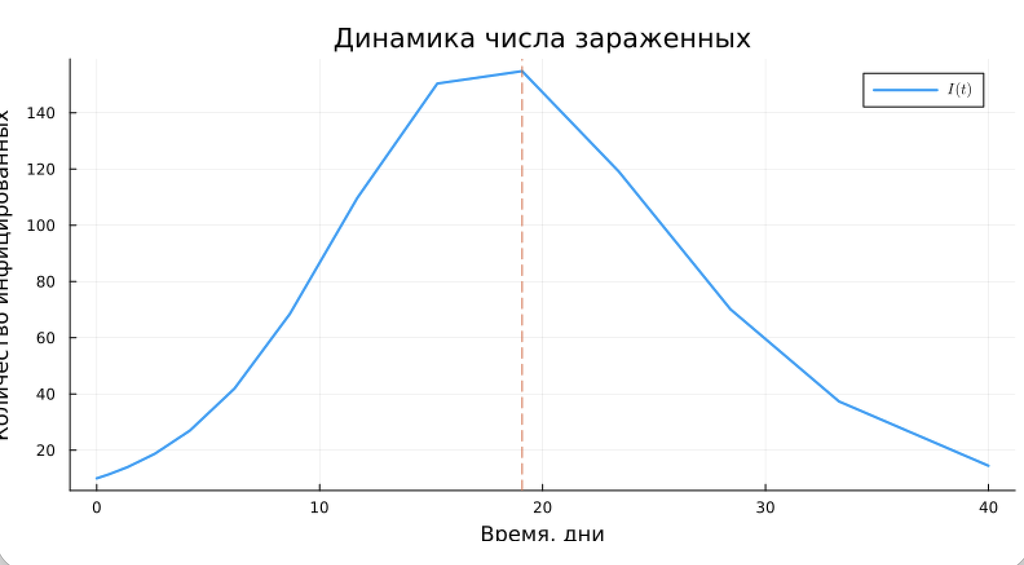

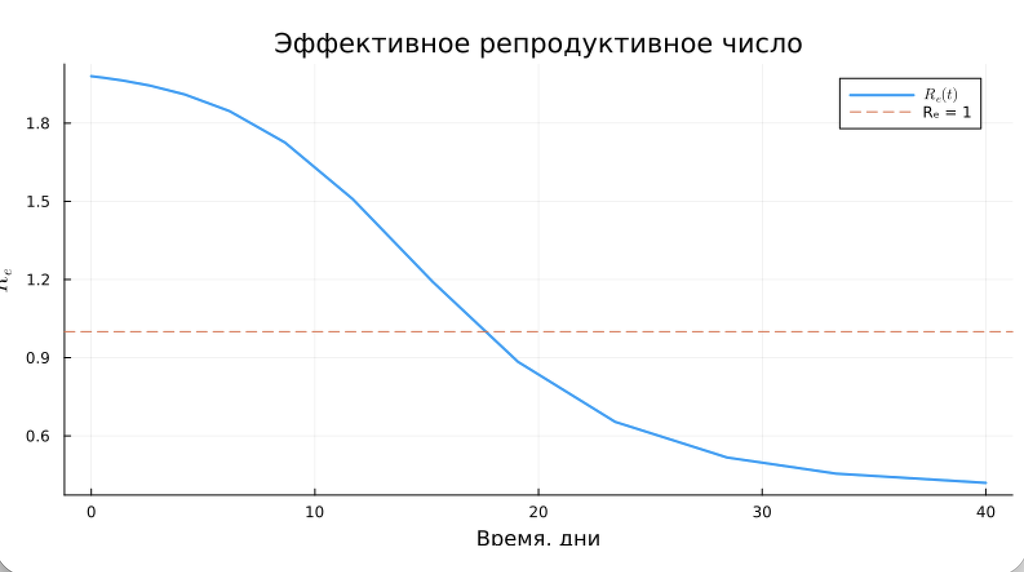

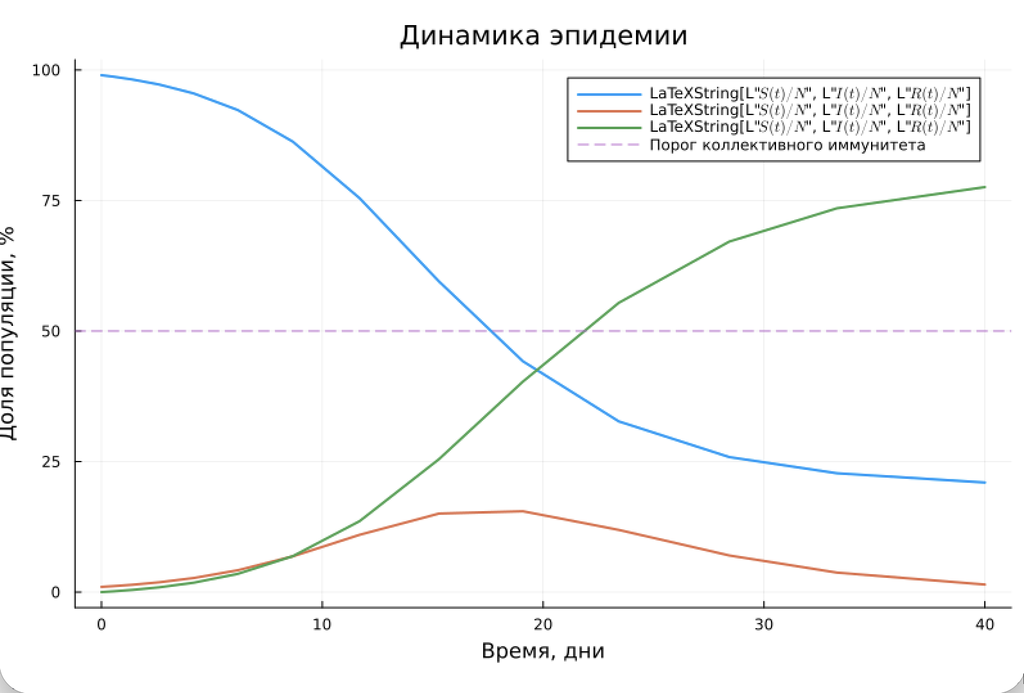

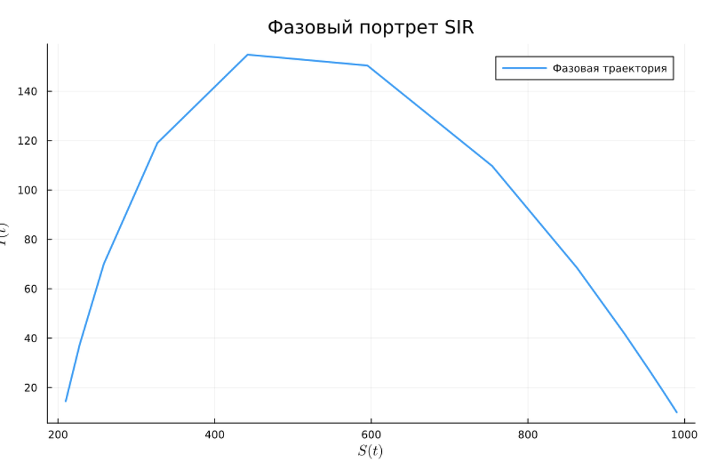

Полученные графики позволяют наблюдать изменение численности трёх групп населения и динамику распространения инфекции.

## 5.3 Параметрическое исследование модели SIR

Для исследования влияния коэффициента передачи инфекции $\beta$ было выполнено параметрическое исследование.

Рассматривались следующие значения:

$$\beta \in \{0.03,\;0.05,\;0.07\}.$$

Для каждого значения параметра рассчитывались:

- максимальное число инфицированных;
- время достижения максимума;
- итоговое число выздоровевших.

Полученные результаты представлены в таблице.

| $\beta$ | $I_{\max}$ | $t_{\text{peak}}$ | $R_{\text{final}}$ |
| --- | --- | --- | --- |
| 0.03 | 22.743 | 36.527 | 187.764 |
| 0.05 | 154.807 | 19.083 | 775.685 |
| 0.07 | 276.454 | 10.969 | 923.128 |

Результат параметрического исследования также представлен на рисунке Рисунок 9.

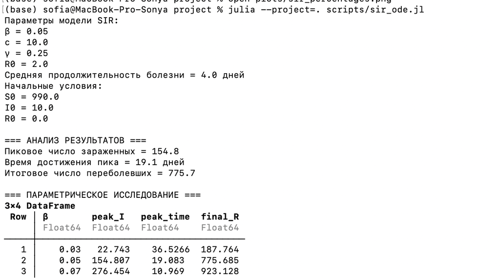

Рисунок 9: Параметрическое исследование модели SIR

Из полученных результатов видно, что увеличение $\beta$ приводит к увеличению максимального числа инфицированных и более раннему достижению пика эпидемии.

При $\beta = 0.03$ максимальное число инфицированных составляет около 22.7 человека, а пик достигается примерно на 36.5-м дне.

При $\beta = 0.05$ максимальное число инфицированных составляет около 154.8 человека, а пик достигается примерно на 19.1-м дне.

При $\beta = 0.07$ максимальное число инфицированных составляет около 276.5 человека, а пик достигается примерно на 11-м дне.

Таким образом, увеличение коэффициента $\beta$ ускоряет распространение инфекции и увеличивает масштаб эпидемии.

## 5.4 Производные файлы модели SIR

Для литературного кода модели SIR были сформированы производные представления:

- Julia-скрипт;
- Jupyter Notebook;
- документ Quarto.

Файлы модели расположены в следующих каталогах:

```
scripts/sir_ode/sir_ode.jl
notebooks/sir_ode/sir_ode.ipynb
markdown/sir_ode/sir_ode.qmd
```

Результат генерации производных файлов представлен на рисунке Рисунок 10.

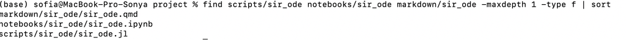

Рисунок 10: Генерация производных файлов модели SIR

# 6 Модель Лотки–Вольтерры

## 6.1 Базовая реализация

Для реализации модели Лотки–Вольтерры был создан Julia-скрипт `lv_ode.jl`.

В базовом эксперименте использовались параметры:

$$\alpha = 0.1,\quad \beta = 0.02,\quad \delta = 0.01,\quad \gamma = 0.3.$$

Начальные условия:

$$x_0 = 40,\quad y_0 = 9.$$

Моделирование проводилось на интервале:

$$t \in [0,200].$$

Стационарная точка определяется выражениями:

$$x^* = \frac{\gamma}{\delta}, \qquad y^* = \frac{\alpha}{\beta}.$$

Для выбранных параметров:

$$x^* = 30,\quad y^* = 5.$$

Результат выполнения модели представлен на рисунке Рисунок 11.

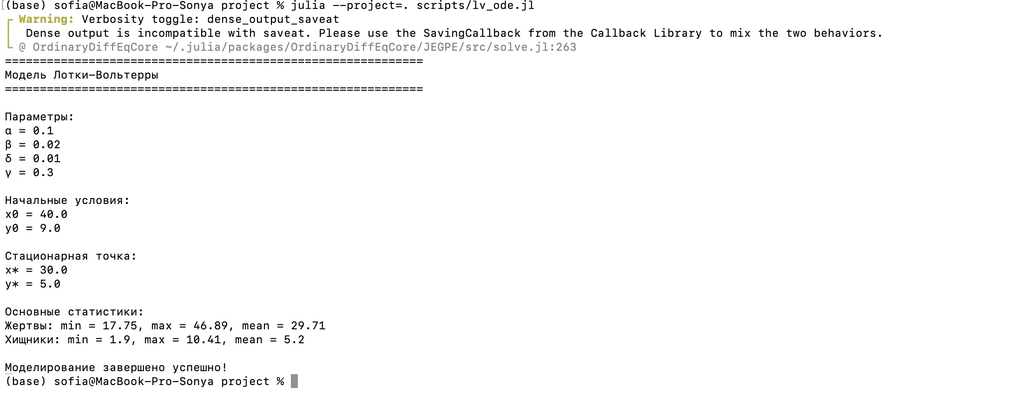

Рисунок 11: Результат выполнения модели Лотки–Вольтерры

## 6.2 Графики модели Лотки–Вольтерры

Для анализа результатов были построены графики динамики популяций, фазового портрета, производных, относительных изменений и спектрального анализа.

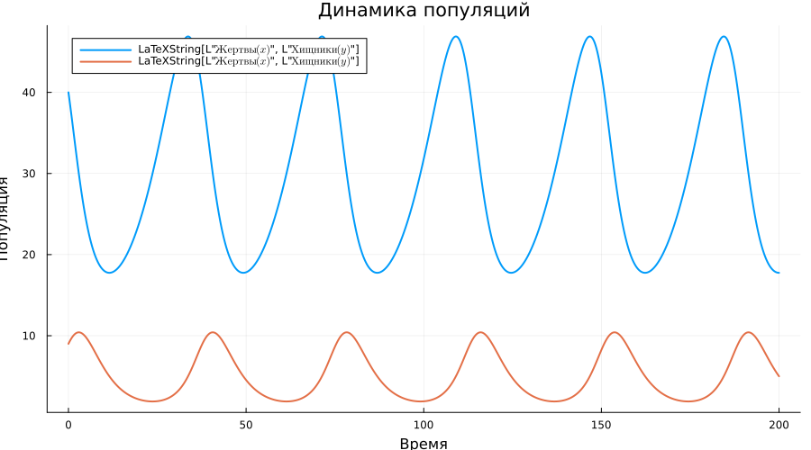

Рисунок 12: Динамика численности жертв и хищников

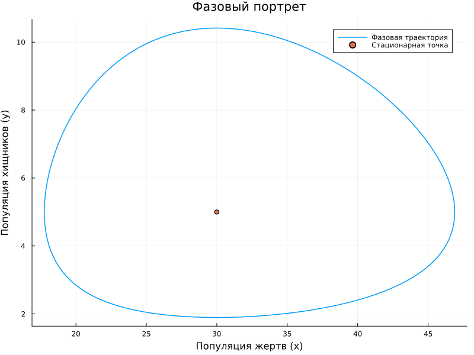

Рисунок 13: Фазовый портрет модели Лотки–Вольтерры

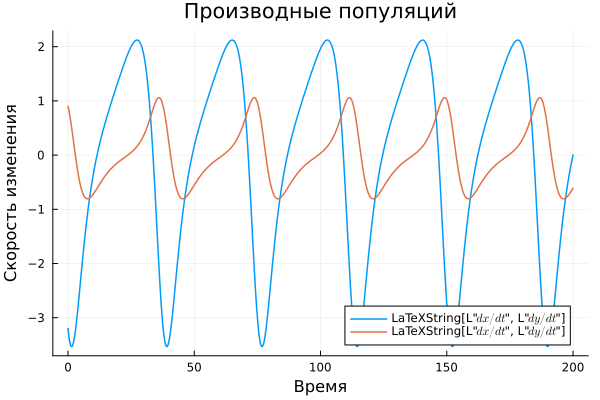

Рисунок 14: Производные численности популяций

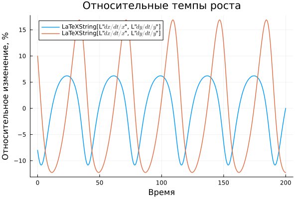

Рисунок 15: Относительные изменения численности популяций

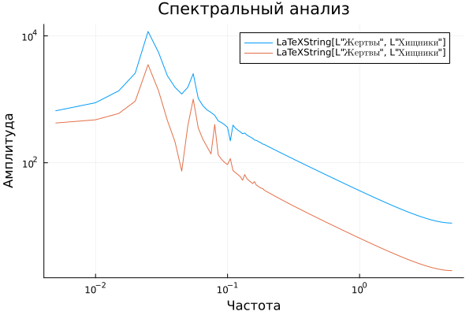

Рисунок 16: Спектральный анализ колебаний численности

Полученные результаты демонстрируют характерные циклические изменения численности жертв и хищников.

## 6.3 Параметрическое исследование модели Лотки–Вольтерры

Для исследования влияния скорости естественного размножения жертв $\alpha$ было выполнено параметрическое исследование.

Рассматривались следующие значения:

$$\alpha \in \{0.05,\;0.1,\;0.2\}.$$

Для каждого значения $\alpha$ выполнялось отдельное численное решение системы.

В результате для каждого эксперимента определялись:

- средняя численность жертв;
- средняя численность хищников;
- максимальная численность жертв;
- максимальная численность хищников.

Результаты параметрического исследования выводились в виде таблицы.

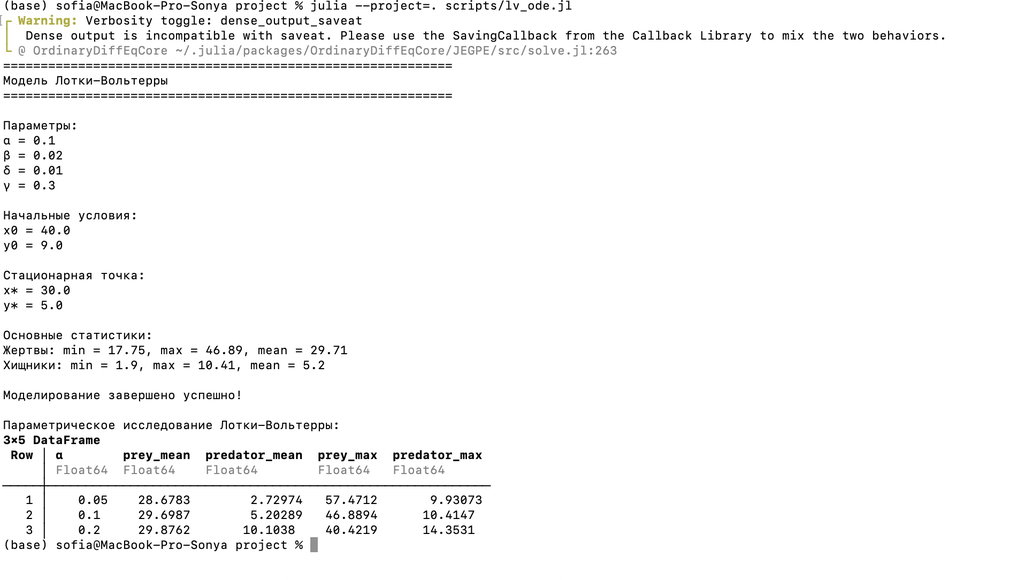

Рисунок 17: Результаты параметрического исследования модели Лотки–Вольтерры

Параметрическое исследование позволяет оценить влияние скорости размножения жертв на динамику обеих популяций.

При изменении $\alpha$ изменяется скорость роста популяции жертв, что также влияет на доступность пищи для хищников и, следовательно, на динамику их численности.

## 6.4 Производные файлы модели Лотки–Вольтерры

Для литературного кода модели Лотки–Вольтерры были сформированы производные представления:

```
scripts/lv_ode/lv_ode.jl
notebooks/lv_ode/lv_ode.ipynb
markdown/lv_ode/lv_ode.qmd
```

Результат генерации файлов представлен на рисунке Рисунок 18.

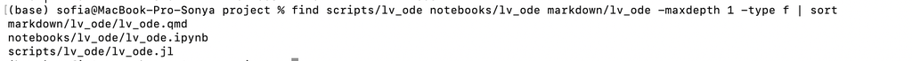

Рисунок 18: Генерация производных файлов модели Лотки–Вольтерры

# 7 Реализация

## 7.1 Модель SIR

### 7.1.1 Базовая реализация

# 8 Модель SIR

Модель SIR описывает распространение инфекции в популяции, разделённой на три группы: восприимчивые, инфицированные и выздоровевшие.

## 8.1 Подключение пакетов

```julia
using DrWatson
@quickactivate "project"

using DifferentialEquations
using SimpleDiffEq
using Tables
using DataFrames
using StatsPlots
using LaTeXStrings
using Plots
using BenchmarkTools
```

## 8.2 Подготовка каталогов

```julia
script_name = splitext(basename(PROGRAM_FILE))[1]

mkpath(plotsdir(script_name))
mkpath(datadir(script_name))
```

```
"/Users/sofia/work/study/2026-1/2026-1==study-simulation-modeling/2026-1--study--simulation-modeling/labs/lab02/project/data/startup"
```

## 8.3 Определение модели SIR

```julia
function sir_ode!(du, u, p, t)

    S, I, R = u
    β, c, γ = p

    N = S + I + R

    @inbounds begin
        du[1] = -β * c * I / N * S
        du[2] = β * c * I / N * S - γ * I
        du[3] = γ * I
    end

    nothing
end
```

```
sir_ode! (generic function with 1 method)
```

## 8.4 Начальные условия и параметры

```julia
δt = 0.1
tmax = 40.0
tspan = (0.0, tmax)

u0 = [990.0, 10.0, 0.0]

p = [
    0.05,
    10.0,
    0.25
]
```

```
3-element Vector{Float64}:
  0.05
 10.0
  0.25
```

## 8.5 Базовое репродуктивное число

```julia
R0 = (p[2] * p[1]) / p[3]
```

```
2.0
```

## 8.6 Формирование задачи Коши

```julia
prob_ode = ODEProblem(
    sir_ode!,
    u0,
    tspan,
    p
)
```

```
ODEProblem with uType Vector{Float64} and tType Float64. In-place: true
Non-trivial mass matrix: false
timespan: (0.0, 40.0)
u0: 3-element Vector{Float64}:
 990.0
  10.0
   0.0
```

## 8.7 Численное решение

```julia
sol_ode = solve(
    prob_ode,
    dt = δt
)
```

```
retcode: Success
Interpolation: 3rd order Hermite
t: 15-element Vector{Float64}:
  0.0
  0.1
  0.5331242537191838
  1.3919008491040001
  2.6102120755226386
  4.1811820758323055
  6.180123810566044
  8.664951930903612
 11.691425331813486
 15.279370667110317
 19.082963490744028
 23.423425193442526
 28.42949373098617
 33.298779173639595
 40.0
u: 15-element Vector{Vector{Float64}}:
 [990.0, 10.0, 0.0]
 [989.4990153200853, 10.247898072276143, 0.25308660763853125]
 [987.1852964117763, 11.391111426852984, 1.4235921613706284]
 [981.8312125227972, 14.026022042698546, 4.14276543450428]
 [972.1392310589528, 18.757815561654187, 9.102953379393007]
 [954.9905500491583, 27.007702518267607, 18.00174743257403]
 [923.0706717929863, 41.92976779832721, 34.999560408686385]
 [862.6705810342164, 68.49345419063417, 68.83596477514932]
 [754.3022993851442, 109.74186185409279, 135.9558387607629]
 [595.1014268847736, 150.41363264480682, 254.48494047041947]
 [442.0141179101299, 154.80694988491865, 403.1789322049513]
 [326.8951167493959, 119.06860394684855, 554.0362793037555]
 [258.5085242188966, 70.11052194753069, 671.3809538335727]
 [227.58338337085726, 37.328570631579986, 735.0880459975627]
 [209.84121402014364, 14.47364496645583, 775.6851410134005]
```

## 8.8 Подготовка результатов

```julia
df_ode = DataFrame(
    Tables.table(sol_ode')
)

rename!(
    df_ode,
    ["S", "I", "R"]
)

df_ode[!, :t] = sol_ode.t

df_ode[!, :N] =
    df_ode.S +
    df_ode.I +
    df_ode.R
```

```
15-element Vector{Float64}:
 1000.0
 1000.0
  999.9999999999999
 1000.0
 1000.0
  999.9999999999999
 1000.0
  999.9999999999999
 1000.0
  999.9999999999999
  999.9999999999998
 1000.0
 1000.0
 1000.0
 1000.0
```

## 8.9 Вывод параметров модели

```julia
println("Параметры модели SIR:")
println("β = ", p[1])
println("c = ", p[2])
println("γ = ", p[3])

println(
    "R0 = ",
    round(R0, digits = 3)
)

println(
    "Средняя продолжительность болезни = ",
    round(1 / p[3], digits = 2),
    " дней"
)
```

```
Параметры модели SIR:
β = 0.05
c = 10.0
γ = 0.25
R0 = 2.0
Средняя продолжительность болезни = 4.0 дней
```

## 8.10 Вывод начальных условий

```julia
println("Начальные условия:")
println("S0 = ", u0[1])
println("I0 = ", u0[2])
println("R0 = ", u0[3])
```

```
Начальные условия:
S0 = 990.0
I0 = 10.0
R0 = 0.0
```

## 8.11 Динамика трёх групп населения

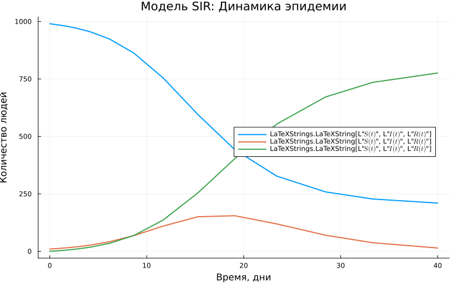

```julia
plt1 = @df df_ode plot(
    :t,
    [:S :I :R],
    label = [
        L"S(t)"
        L"I(t)"
        L"R(t)"
    ],
    xlabel = "Время, дни",
    ylabel = "Количество людей",
    title = "Модель SIR: Динамика эпидемии",
    linewidth = 2,
    legend = :right,
    grid = true,
    size = (800, 500)
)
```

## 8.12 Поиск пика эпидемии

```julia
peak_idx = argmax(df_ode.I)

peak_time =
    df_ode.t[peak_idx]

peak_value =
    df_ode.I[peak_idx]
```

```
154.80694988491865
```

## 8.13 Динамика числа инфицированных

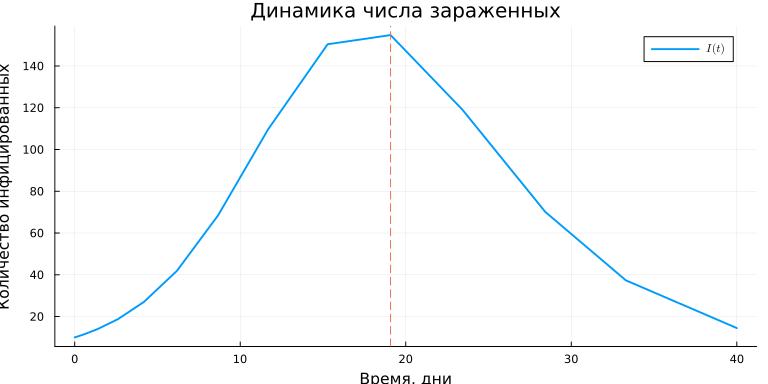

```julia
plt2 = @df df_ode plot(
    :t,
    :I,
    label = L"I(t)",
    xlabel = "Время, дни",
    ylabel = "Количество инфицированных",
    title = "Динамика числа зараженных",
    linewidth = 2,
    grid = true,
    size = (800, 400)
)

vline!(
    plt2,
    [peak_time],
    linestyle = :dash,
    label = false
)
```

## 8.14 Анализ экспоненциального роста

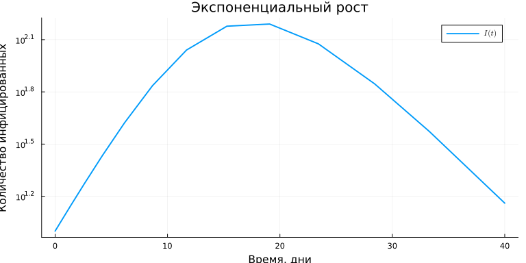

```julia
plt3 = @df df_ode plot(
    :t,
    :I,
    label = L"I(t)",
    xlabel = "Время, дни",
    ylabel = "Количество инфицированных",
    title = "Экспоненциальный рост",
    yscale = :log10,
    linewidth = 2,
    grid = true,
    size = (800, 400)
)
```

## 8.15 Доли групп населения

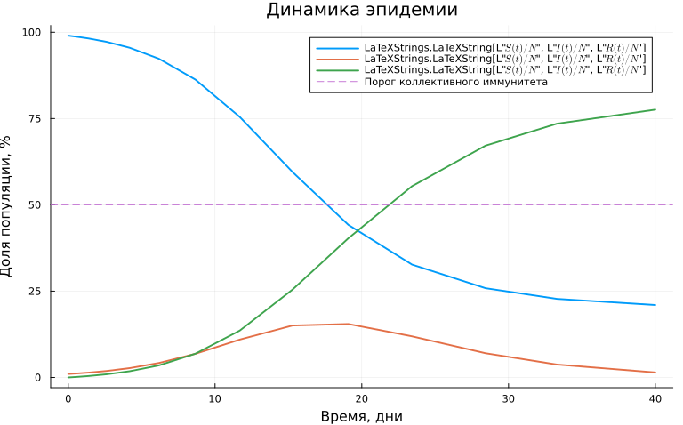

```julia
plt4 = @df df_ode plot(
    :t,
    [:S :I :R] ./ df_ode.N .* 100,
    label = [
        L"S(t)/N"
        L"I(t)/N"
        L"R(t)/N"
    ],
    xlabel = "Время, дни",
    ylabel = "Доля популяции, %",
    title = "Динамика эпидемии",
    linewidth = 2,
    grid = true,
    size = (800, 500)
)

if R0 > 1

    herd_immunity_threshold =
        (1 - 1 / R0) * 100

    hline!(
        plt4,
        [herd_immunity_threshold],
        linestyle = :dash,
        label = "Порог коллективного иммунитета"
    )

end
```

## 8.16 Фазовый портрет

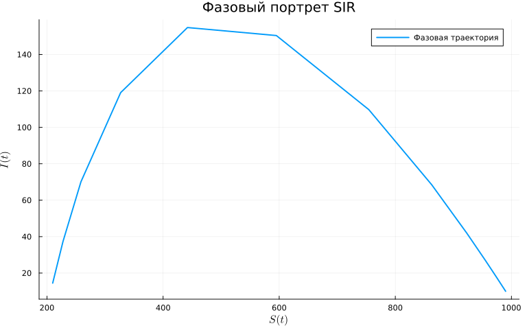

```julia
plt5 = plot(
    df_ode.S,
    df_ode.I,
    label = "Фазовая траектория",
    xlabel = L"S(t)",
    ylabel = L"I(t)",
    title = "Фазовый портрет SIR",
    linewidth = 2,
    grid = true,
    size = (800, 500)
)
```

## 8.17 Эффективное репродуктивное число

```julia
df_ode[!, :Re] =
    R0 .* df_ode.S ./ df_ode.N
```

```
15-element Vector{Float64}:
 1.98
 1.9789980306401707
 1.9743705928235529
 1.9636624250455943
 1.9442784621179054
 1.909981100098317
 1.8461413435859726
 1.725341162068433
 1.5086045987702885
 1.1902028537695473
 0.88402823582026
 0.6537902334987918
 0.5170170484377932
 0.4551667667417145
 0.41968242804028727
```

## 8.18 Динамика эффективного репродуктивного числа

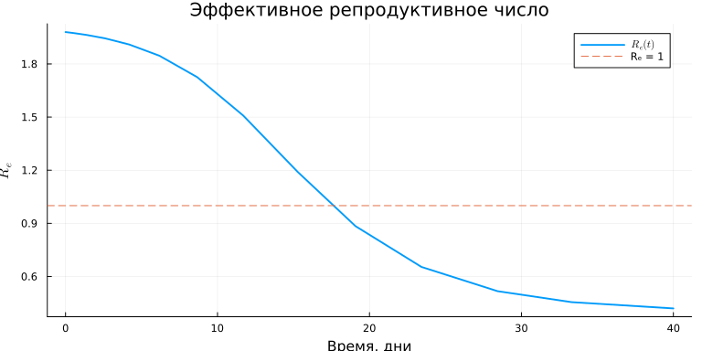

```julia
plt6 = @df df_ode plot(
    :t,
    :Re,
    label = L"R_e(t)",
    xlabel = "Время, дни",
    ylabel = L"R_e",
    title = "Эффективное репродуктивное число",
    linewidth = 2,
    grid = true,
    size = (800, 400)
)

hline!(
    plt6,
    [1.0],
    linestyle = :dash,
    label = "Rₑ = 1"
)
```

## 8.19 Сохранение графиков

```julia
savefig(
    plt1,
    plotsdir(
        script_name,
        "sir_main.png"
    )
)

savefig(
    plt2,
    plotsdir(
        script_name,
        "sir_infected.png"
    )
)

savefig(
    plt3,
    plotsdir(
        script_name,
        "sir_log_scale.png"
    )
)

savefig(
    plt4,
    plotsdir(
        script_name,
        "sir_percentages.png"
    )
)

savefig(
    plt5,
    plotsdir(
        script_name,
        "sir_phase_portrait.png"
    )
)

savefig(
    plt6,
    plotsdir(
        script_name,
        "sir_effective_R.png"
    )
)
```

```
"/Users/sofia/work/study/2026-1/2026-1==study-simulation-modeling/2026-1--study--simulation-modeling/labs/lab02/project/plots/startup/sir_effective_R.png"
```

## 8.20 Анализ результатов

```julia
println(
    "\n=== АНАЛИЗ РЕЗУЛЬТАТОВ ==="
)

println(
    "Пиковое число зараженных = ",
    round(peak_value, digits = 1)
)

println(
    "Время достижения пика = ",
    round(peak_time, digits = 1),
    " дней"
)

println(
    "Итоговое число переболевших = ",
    round(df_ode.R[end], digits = 1)
)
```

```
=== АНАЛИЗ РЕЗУЛЬТАТОВ ===
Пиковое число зараженных = 154.8
Время достижения пика = 19.1 дней
Итоговое число переболевших = 775.7
```

## 8.21 Оценка производительности

```julia
@benchmark solve(
    prob_ode,
    dt = δt
)
```

```
BenchmarkTools.Trial: 10000 samples with 1 evaluation per sample.
 Range (min … max):  13.360 μs …   9.791 ms  ┊ GC (min … max):  0.00% … 98.73%
 Time  (median):     15.457 μs               ┊ GC (median):     0.00%
 Time  (mean ± σ):   21.469 μs ± 191.936 μs  ┊ GC (mean ± σ):  21.46% ±  2.42%

    ▄█▇▃
  ▁▄████▆▄▃▂▂▂▂▂▂▂▂▂▁▁▁▁▁▁▁▁▁▁▁▁▁▁▁▁▁▁▁▁▁▁▁▁▁▁▁▁▁▁▁▁▁▁▁▁▁▁▁▁▁▁ ▂
  13.4 μs         Histogram: frequency by time         40.8 μs <

 Memory estimate: 42.20 KiB, allocs estimate: 441.
```

## 8.22 Параметрическое исследование

Исследуем влияние коэффициента β на развитие эпидемии.

Для сравнения рассматриваем несколько значений β.

```julia
β_values = [
    0.03,
    0.05,
    0.07
]

sir_parameter_results = []

for β_value in β_values

    p_test = [
        β_value,
        10.0,
        0.25
    ]

    prob_test = ODEProblem(
        sir_ode!,
        u0,
        tspan,
        p_test
    )

    sol_test = solve(
        prob_test,
        dt = δt
    )

    peak_idx_test =
        argmax(
            [u[2] for u in sol_test.u]
        )

    peak_value_test =
        sol_test.u[peak_idx_test][2]

    peak_time_test =
        sol_test.t[peak_idx_test]

    final_recovered_test =
        sol_test.u[end][3]

    push!(
        sir_parameter_results,
        (
            β = β_value,
            peak_I = peak_value_test,
            peak_time = peak_time_test,
            final_R = final_recovered_test
        )
    )

end
```

## 8.23 Таблица результатов параметрического исследования

```julia
df_parameter =
    DataFrame(
        sir_parameter_results
    )

println(
    "\n=== ПАРАМЕТРИЧЕСКОЕ ИССЛЕДОВАНИЕ ==="
)

println(
    df_parameter
)
```

```
=== ПАРАМЕТРИЧЕСКОЕ ИССЛЕДОВАНИЕ ===
3×4 DataFrame
 Row │ β        peak_I   peak_time  final_R
     │ Float64  Float64  Float64    Float64
─────┼──────────────────────────────────────
   1 │    0.03   22.743    36.5266  187.764
   2 │    0.05  154.807    19.083   775.685
   3 │    0.07  276.454    10.969   923.128
```

## 8.24 Сравнение результатов

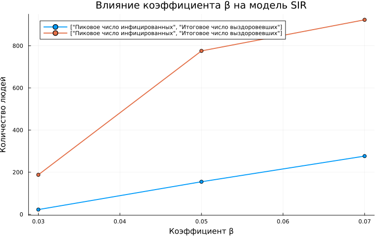

```julia
plt_parameter = plot(
    df_parameter.β,
    [
        df_parameter.peak_I df_parameter.final_R
    ],
    label = [
        "Пиковое число инфицированных"
        "Итоговое число выздоровевших"
    ],
    marker = :circle,
    xlabel = "Коэффициент β",
    ylabel = "Количество людей",
    title = "Влияние коэффициента β на модель SIR",
    linewidth = 2,
    grid = true,
    size = (800, 500)
)
```

## 8.25 Сохранение результата параметрического исследования

```julia
savefig(
    plt_parameter,
    plotsdir(
        script_name,
        "sir_parameter_scan.png"
    )
)

println(
    "\nПараметрическое исследование завершено."
)

println(
    "График сохранён в: ",
    plotsdir(
        script_name,
        "sir_parameter_scan.png"
    )
)
```

```
Параметрическое исследование завершено.
График сохранён в: /Users/sofia/work/study/2026-1/2026-1==study-simulation-modeling/2026-1--study--simulation-modeling/labs/lab02/project/plots/startup/sir_parameter_scan.png
```

## 8.26 Модель Лотки–Вольтерры

### 8.26.1 Базовая реализация

# 9 Модель Лотки–Вольтерры

Модель Лотки–Вольтерры описывает взаимодействие двух популяций: жертв и хищников.

x — численность жертв; y — численность хищников.

## 9.1 Подключение пакетов

Используем DifferentialEquations для решения системы дифференциальных уравнений, DataFrames для обработки результатов и Plots для построения графиков.

```julia
using DrWatson
@quickactivate "project"

using DifferentialEquations
using DataFrames
using StatsPlots
using LaTeXStrings
using Plots
using Statistics
using FFTW
```

## 9.2 Подготовка каталогов

Определяем имя скрипта и создаём каталоги для сохранения результатов и графиков.

```julia
script_name = splitext(basename(PROGRAM_FILE))[1]

mkpath(plotsdir(script_name))
mkpath(datadir(script_name))
```

```
"/Users/sofia/work/study/2026-1/2026-1==study-simulation-modeling/2026-1--study--simulation-modeling/labs/lab02/project/data/startup"
```

## 9.3 Определение модели

Система Лотки–Вольтерры имеет вид:

dx/dt = αx - βxy

dy/dt = δxy - γy

где:

α — скорость естественного роста жертв; β — интенсивность взаимодействия жертв и хищников; δ — эффективность превращения добычи в прирост хищников; γ — скорость естественного уменьшения численности хищников.

```julia
function lotka_volterra!(du, u, p, t)

    x, y = u

    α, β, δ, γ = p

    @inbounds begin

        du[1] =
            α * x -
            β * x * y

        du[2] =
            δ * x * y -
            γ * y

    end

    nothing
end
```

```
lotka_volterra! (generic function with 1 method)
```

## 9.4 Параметры модели

Задаём значения параметров модели и начальные численности популяций.

```julia
p_lv = [
    0.1,
    0.02,
    0.01,
    0.3
]

u0_lv = [
    40.0,
    9.0
]
```

```
2-element Vector{Float64}:
 40.0
  9.0
```

## 9.5 Интервал моделирования

Исследуем динамику популяций на интервале от 0 до 200 единиц времени.

```julia
tspan_lv = (
    0.0,
    200.0
)

dt_lv = 0.01
```

```
0.01
```

## 9.6 Формирование задачи

Создаём задачу Коши для системы дифференциальных уравнений.

```julia
prob_lv = ODEProblem(
    lotka_volterra!,
    u0_lv,
    tspan_lv,
    p_lv
)
```

```
ODEProblem with uType Vector{Float64} and tType Float64. In-place: true
Non-trivial mass matrix: false
timespan: (0.0, 200.0)
u0: 2-element Vector{Float64}:
 40.0
  9.0
```

## 9.7 Численное решение

Решаем систему численно с помощью метода Tsit5.

Сохраняем результаты через каждые 0.1 единицы времени.

```julia
sol_lv = solve(
    prob_lv,
    Tsit5(),
    dt=dt_lv,
    reltol=1e-8,
    abstol=1e-10,
    saveat=0.1,
    dense=true
)
```

```
┌ Warning: Verbosity toggle: dense_output_saveat
│  Dense output is incompatible with saveat. Please use the SavingCallback from the Callback Library to mix the two behaviors.
└ @ OrdinaryDiffEqCore ~/.julia/packages/OrdinaryDiffEqCore/JEGPE/src/solve.jl:263
```

```
retcode: Success
Interpolation: specialized 4th order "free" interpolation
t: 2001-element Vector{Float64}:
   0.0
   0.1
   0.2
   0.3
   0.4
   0.5
   0.6
   0.7
   0.8
   0.9
   ⋮
 199.2
 199.3
 199.4
 199.5
 199.6
 199.7
 199.8
 199.9
 200.0
u: 2001-element Vector{Vector{Float64}}:
 [40.0, 9.0]
 [39.67773201890384, 9.088990237207637]
 [39.35113789503168, 9.175882726306998]
 [39.02053587808482, 9.260562174341327]
 [38.68624820281499, 9.342916311942014]
 [38.34860018759226, 9.422836265415745]
 [38.007919320045765, 9.5002169187062]
 [37.664534369328166, 9.574957250330058]
 [37.31877446654823, 9.646960666854817]
 [36.9709682176784, 9.716135308317774]
 ⋮
 [17.824353144929315, 5.508019318506856]
 [17.807442037033756, 5.441315154551648]
 [17.792907686320664, 5.375334300040311]
 [17.780718473179327, 5.310082577777411]
 [17.770843588540227, 5.24556508481173]
 [17.76325301314863, 5.181786245480946]
 [17.75791751745926, 5.118749811721092]
 [17.754808657966564, 5.056458873592464]
 [17.75389874795971, 4.994915937053478]
```

## 9.8 Подготовка результатов

Переносим результаты решения в DataFrame, чтобы упростить дальнейший анализ.

```julia
df_lv = DataFrame()

df_lv[!, :t] =
    sol_lv.t

df_lv[!, :prey] =
    [u[1] for u in sol_lv.u]

df_lv[!, :predator] =
    [u[2] for u in sol_lv.u]
```

```
2001-element Vector{Float64}:
 9.0
 9.088990237207637
 9.175882726306998
 9.260562174341327
 9.342916311942014
 9.422836265415745
 9.5002169187062
 9.574957250330058
 9.646960666854817
 9.716135308317774
 ⋮
 5.508019318506856
 5.441315154551648
 5.375334300040311
 5.310082577777411
 5.24556508481173
 5.181786245480946
 5.118749811721092
 5.056458873592464
 4.994915937053478
```

## 9.9 Производные популяций

Рассчитываем скорость изменения численности жертв и хищников.

```julia
df_lv[!, :dprey_dt] =
    p_lv[1] .* df_lv.prey .-
    p_lv[2] .* df_lv.prey .* df_lv.predator

df_lv[!, :dpredator_dt] =
    p_lv[3] .* df_lv.prey .* df_lv.predator .-
    p_lv[4] .* df_lv.predator
```

```
2001-element Vector{Float64}:
  0.9000000000000004
  0.8796081183812872
  0.8580494468233599
  0.8353523334488111
  0.8115489002365717
  0.7866749261310111
  0.7607697060793308
  0.7338758893000268
  0.706039294083721
  0.677308704329461
  ⋮
 -0.6706369809304658
 -0.6634355041663761
 -0.6561720201747897
 -0.648853939485278
 -0.6414883588865488
 -0.6340820722589682
 -0.6266415740257949
 -0.6191730642026259
 -0.611682463105866
```

## 9.10 Стационарная точка

Для модели Лотки–Вольтерры внутренняя стационарная точка определяется выражениями:

x* = γ / δ

y* = α / β

```julia
x_star =
    p_lv[4] / p_lv[3]

y_star =
    p_lv[1] / p_lv[2]
```

```
5.0
```

## 9.11 Вывод параметров

Выводим основные параметры и начальные условия используемой модели.

```julia
println("="^60)

println(
    "Модель Лотки-Вольтерры"
)

println("="^60)

println("\nПараметры:")

println("α = ", p_lv[1])

println("β = ", p_lv[2])

println("δ = ", p_lv[3])

println("γ = ", p_lv[4])

println("\nНачальные условия:")

println("x0 = ", u0_lv[1])

println("y0 = ", u0_lv[2])

println("\nСтационарная точка:")

println("x* = ", x_star)

println("y* = ", y_star)
```

```
============================================================
Модель Лотки-Вольтерры
============================================================

Параметры:
α = 0.1
β = 0.02
δ = 0.01
γ = 0.3

Начальные условия:
x0 = 40.0
y0 = 9.0

Стационарная точка:
x* = 30.0
y* = 5.0
```

## 9.12 Динамика популяций

Строим график изменения численности жертв и хищников во времени.

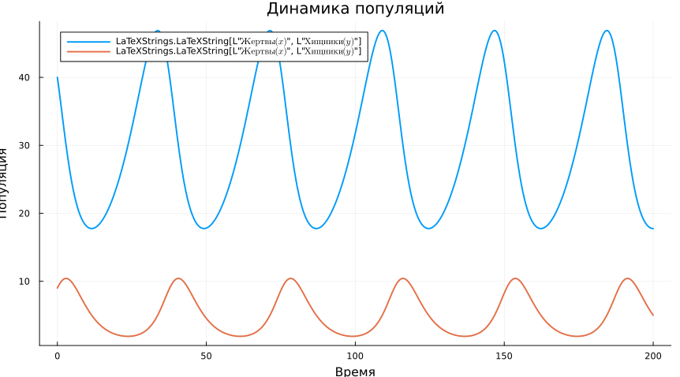

```julia
plt1 = plot(
    df_lv.t,
    [df_lv.prey df_lv.predator],
    label=[
        L"Жертвы (x)"
        L"Хищники (y)"
    ],
    xlabel="Время",
    ylabel="Популяция",
    title="Динамика популяций",
    linewidth=2,
    grid=true,
    size=(900, 500)
)
```

## 9.13 Фазовый портрет

Строим зависимость численности хищников от численности жертв.

Дополнительно отмечаем стационарную точку.

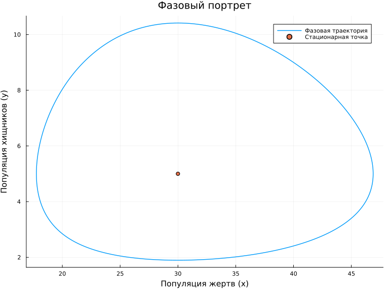

```julia
plt2 = plot(
    df_lv.prey,
    df_lv.predator,
    label="Фазовая траектория",
    xlabel="Популяция жертв (x)",
    ylabel="Популяция хищников (y)",
    title="Фазовый портрет",
    linewidth=1.5,
    grid=true,
    size=(800, 600)
)

scatter!(
    plt2,
    [x_star],
    [y_star],
    label="Стационарная точка"
)
```

## 9.14 Производные популяций

Отображаем скорость изменения численности обеих популяций.

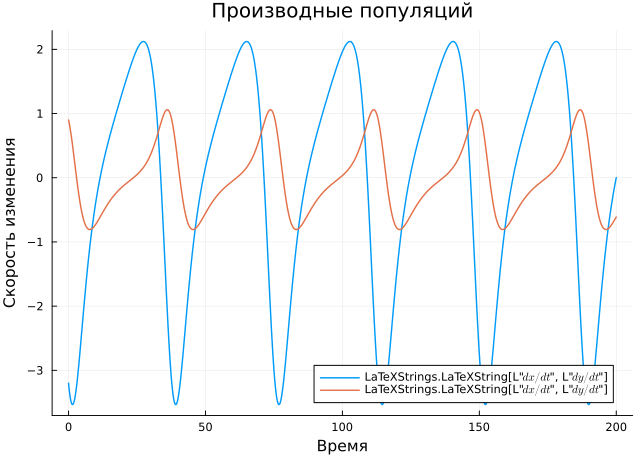

```julia
plt3 = plot(
    df_lv.t,
    [df_lv.dprey_dt df_lv.dpredator_dt],
    label=[
        L"dx/dt"
        L"dy/dt"
    ],
    xlabel="Время",
    ylabel="Скорость изменения",
    title="Производные популяций",
    linewidth=1.5,
    grid=true
)
```

## 9.15 Относительные изменения

Рассчитываем относительные темпы изменения численности жертв и хищников.

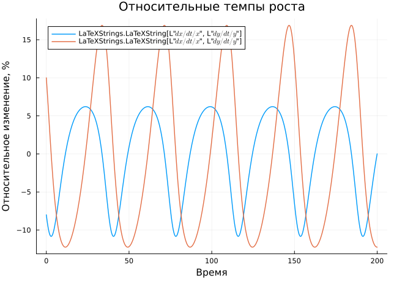

```julia
df_lv[!, :prey_pct_change] =
    df_lv.dprey_dt ./ df_lv.prey .* 100

df_lv[!, :predator_pct_change] =
    df_lv.dpredator_dt ./ df_lv.predator .* 100

plt4 = plot(
    df_lv.t,
    [
        df_lv.prey_pct_change df_lv.predator_pct_change
    ],
    label=[
        L"dx/dt / x"
        L"dy/dt / y"
    ],
    xlabel="Время",
    ylabel="Относительное изменение, %",
    title="Относительные темпы роста",
    linewidth=1.5,
    grid=true
)
```

## 9.16 Спектральный анализ

Используем быстрое преобразование Фурье для исследования периодичности колебаний численности популяций.

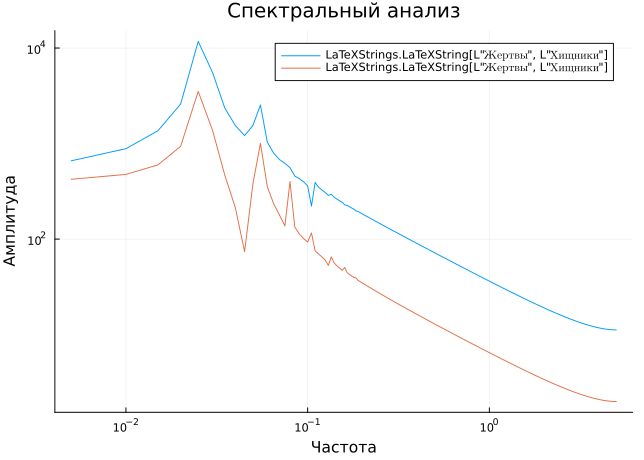

```julia
function compute_fft(signal, dt)

    n = length(signal)

    spectrum =
        abs.(rfft(signal))

    freq =
        rfftfreq(n, 1 / dt)

    return freq, spectrum

end

freq_prey, spectrum_prey =
    compute_fft(
        df_lv.prey .- mean(df_lv.prey),
        0.1
    )

freq_predator, spectrum_predator =
    compute_fft(
        df_lv.predator .- mean(df_lv.predator),
        0.1
    )

plt5 = plot(
    freq_prey[2:end],
    [
        spectrum_prey[2:end] spectrum_predator[2:end]
    ],
    label=[
        L"Жертвы"
        L"Хищники"
    ],
    xlabel="Частота",
    ylabel="Амплитуда",
    title="Спектральный анализ",
    xscale=:log10,
    yscale=:log10,
    grid=true
)
```

## 9.17 Сохранение графиков

Сохраняем результаты визуализации в каталог plots проекта.

```julia
savefig(
    plt1,
    plotsdir(
        script_name,
        "lv_dynamics.png"
    )
)

savefig(
    plt2,
    plotsdir(
        script_name,
        "lv_phase_portrait.png"
    )
)

savefig(
    plt3,
    plotsdir(
        script_name,
        "lv_derivatives.png"
    )
)

savefig(
    plt4,
    plotsdir(
        script_name,
        "lv_relative_changes.png"
    )
)

savefig(
    plt5,
    plotsdir(
        script_name,
        "lv_spectrum.png"
    )
)
```

```
"/Users/sofia/work/study/2026-1/2026-1==study-simulation-modeling/2026-1--study--simulation-modeling/labs/lab02/project/plots/startup/lv_spectrum.png"
```

## 9.18 Статистический анализ

Рассчитываем минимальные, максимальные и средние значения численности обеих популяций.

```julia
println("\nОсновные статистики:")

println(
    "Жертвы: min = ",
    round(
        minimum(df_lv.prey),
        digits=2
    ),
    ", max = ",
    round(
        maximum(df_lv.prey),
        digits=2
    ),
    ", mean = ",
    round(
        mean(df_lv.prey),
        digits=2
    )
)

println(
    "Хищники: min = ",
    round(
        minimum(df_lv.predator),
        digits=2
    ),
    ", max = ",
    round(
        maximum(df_lv.predator),
        digits=2
    ),
    ", mean = ",
    round(
        mean(df_lv.predator),
        digits=2
    )
)

println(
    "\nМоделирование завершено успешно!"
)
```

```
Основные статистики:
Жертвы: min = 17.75, max = 46.89, mean = 29.71
Хищники: min = 1.9, max = 10.41, mean = 5.2

Моделирование завершено успешно!
```

## 9.19 Параметрическое исследование

Исследуем влияние параметра α, отвечающего за естественный рост популяции жертв.

Рассматриваем несколько значений α.

```julia
α_values = [
    0.05,
    0.1,
    0.2
]

lv_parameter_results = []

for α_value in α_values
    p_test = [
        α_value,
        0.02,
        0.01,
        0.3
    ]

    prob_test = ODEProblem(
        lotka_volterra!,
        u0_lv,
        tspan_lv,
        p_test
    )

    sol_test = solve(
        prob_test,
        Tsit5(),
        dt=dt_lv,
        saveat=0.1
    )

    prey_values = [u[1] for u in sol_test.u]
    predator_values = [u[2] for u in sol_test.u]

    push!(
        lv_parameter_results,
        (
            α=α_value,
            prey_mean=mean(prey_values),
            predator_mean=mean(predator_values),
            prey_max=maximum(prey_values),
            predator_max=maximum(predator_values)
        )
    )
end

lv_parameter_df = DataFrame(
    lv_parameter_results
)

println(
    "\nПараметрическое исследование Лотки-Вольтерры:"
)

println(
    lv_parameter_df
)
```

```
Параметрическое исследование Лотки-Вольтерры:
3×5 DataFrame
 Row │ α        prey_mean  predator_mean  prey_max  predator_max
     │ Float64  Float64    Float64        Float64   Float64
─────┼───────────────────────────────────────────────────────────
   1 │    0.05    28.6783        2.72974   57.4712       9.93073
   2 │    0.1     29.6987        5.20289   46.8894      10.4147
   3 │    0.2     29.8762       10.1038    40.4219      14.3531
```

## 9.20 Выполнение Jupyter Notebook

После генерации производных файлов были выполнены Jupyter Notebook для обеих моделей.

Для модели SIR использовался файл:

```
notebooks/sir_ode/sir_ode.ipynb
```

Для модели Лотки–Вольтерры:

```
notebooks/lv_ode/lv_ode.ipynb
```

Результат выполнения Jupyter Notebook модели SIR представлен на рисунке Рисунок 19.

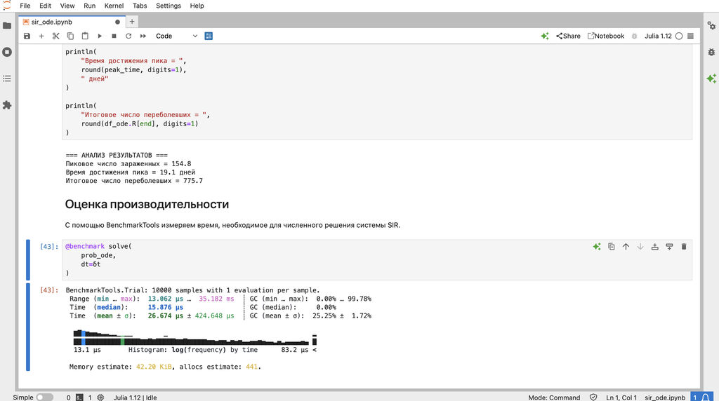

Рисунок 19: Результат выполнения Jupyter Notebook модели SIR

Результат выполнения Jupyter Notebook модели Лотки–Вольтерры представлен на рисунке Рисунок 20.

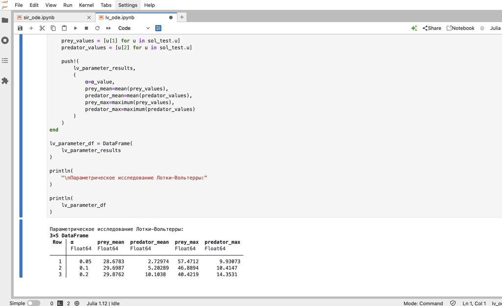

Рисунок 20: Результат выполнения Jupyter Notebook модели Лотки–Вольтерры

# 10 Литературное программирование

Для преобразования программного кода использовался литературный стиль программирования.

Исходные Julia-скрипты содержат текстовые пояснения в виде комментариев. Это позволяет одновременно использовать их как исполняемые программы и как основу для формирования документации.

Для генерации производных представлений использовался скрипт:

```
scripts/tangle.jl
```

В результате для моделей были получены Julia-скрипты, Jupyter Notebook и документы Quarto.

# 11 Анализ результатов

## 11.1 Модель SIR

В базовом эксперименте при

$$\beta = 0.05,\quad c = 10,\quad \gamma = 0.25$$

получено:

$$R_0 = 2.$$

Пиковое число инфицированных составляет около 154.8 человека, а момент достижения пика — примерно 19.1 дня.

Итоговое число выздоровевших составляет около 775.7 человека.

Параметрическое исследование показало существенное влияние коэффициента $\beta$ на динамику заболевания.

При увеличении $\beta$ максимальное число инфицированных увеличивается, а пик эпидемии достигается раньше.

Таким образом, увеличение интенсивности передачи инфекции приводит к более быстрому и масштабному распространению заболевания.

## 11.2 Модель Лотки–Вольтерры

В базовом эксперименте при

$$\alpha = 0.1,\quad \beta = 0.02,\quad \delta = 0.01,\quad \gamma = 0.3$$

наблюдаются циклические изменения численности жертв и хищников.

Стационарная точка для заданных параметров равна:

$$(x^*, y^*) = (30, 5).$$

Полученные графики показывают взаимосвязь между изменением численности двух популяций.

В параметрическом исследовании рассматривались значения:

$$\alpha \in \{0.05,\;0.1,\;0.2\}.$$

Изменение $\alpha$ влияет на скорость роста популяции жертв и вследствие взаимодействия между видами отражается на динамике хищников.

# 12 Выводы

В ходе выполнения лабораторной работы были изучены и реализованы две математические модели: SIR и Лотки–Вольтерры.

Для модели SIR было выполнено базовое моделирование и параметрическое исследование коэффициента $\beta$ для значений:

$$\beta \in \{0.03,\;0.05,\;0.07\}.$$

Было установлено, что увеличение $\beta$ приводит к увеличению максимального числа инфицированных и более раннему достижению пика эпидемии.

Для модели Лотки–Вольтерры была исследована динамика взаимодействия популяций жертв и хищников. Были построены графики динамики популяций, фазового портрета, производных, относительных изменений и спектрального анализа.

Также было выполнено параметрическое исследование влияния $\alpha$ для значений:

$$\alpha \in \{0.05,\;0.1,\;0.2\}.$$

В рамках лабораторной работы были освоены численное решение систем дифференциальных уравнений в Julia, литературное программирование, генерация Jupyter Notebook и документов Quarto, а также проведение параметрических исследований.

# Список литературы